# Test 2, STAT 245 for dnv5

Author

STAT 245 Fall 2024

## Response variable

Fit a regression model using as your response variable: whether the person agrees to support the creation of a fund to reduce air pollution.

## Data Access

You can find your data at: https://sldr.netlify.app/data/vietnam-air.csv

## Context

This dataset was recently analyzed by Quan-Hoang Vuong and colleagues in the paper [*Exploring Inner-City Residents’ and Foreigners’ Commitment to Improving Air Pollution: Evidence from a Field Survey in Hanoi, Vietnam*](https://www.mdpi.com/2306-5729/6/4/39).

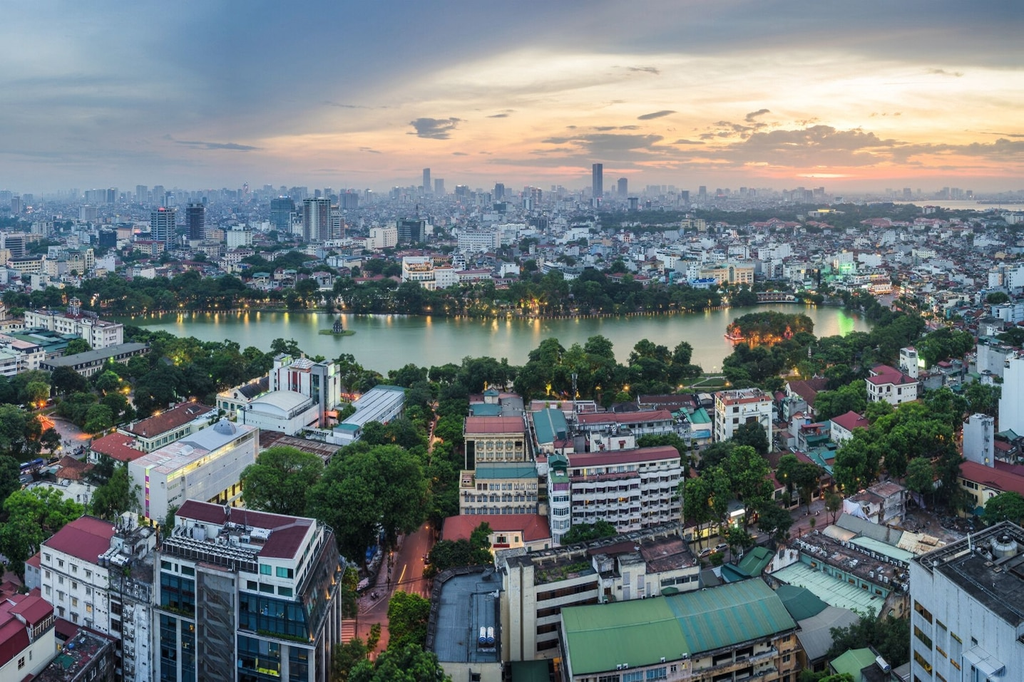

Image from Getty Images at nationalgeographic.com

The authors say,

> > Solutions for mitigating and reducing environmental pollution are important priorities for many developed and developing countries. This study was conducted to better understand the degree to which inner-city citizens and foreigners perceive air pollution and respond to it, particularly how much they willingly contribute to improving air quality in Vietnam, a lower-middle-income nation in Southeast Asia. During mid-December 2019, a stratified random sampling technique and a contingent valuation method (CVM) were employed to survey 199 inhabitants and 75 foreigners who reside and travel within the inner-city of Hanoi. The data comprises four major groups of information on: (1) perception of air pollution and its impacts, (2) preventive measures used to mitigate polluted air, (3) commitments on willingness-to-pay (WTP) for reducing air pollution alongside reasons for the yes-or-no-WTP decision, and (4) demographic information of interviewees. The findings and data of this study could offer many policy implications for better environmental management in the study area and beyond.

Variables in the data set include:

- Demographic information about each household:
  - an `ID` number
  - the `Location` where they live
  - the `Education` level, `AgeGroup`, and `Sex` of the person completing the survey, plus whether they are head of the household (`MainInHouse`)
  - whether the person works inside or outside (`WorkingPlace`)
  - the number of residents in the household, `NumHouse`
  - `IncomeRegular`, the regular income of the household in millions of Vietnam Dong (categorical)
  - `IncomeNotRegular`, the non-regular (occasional, sometimes present and sometimes not) income of the household in millions of Vietnam Dong (categorical)
- `AirDistrict`: Answer to the question, “To what extent do you feel about the air quality in your area?”
- `AirVsOtherDistrict`: Answer to the question, “Does the air quality vary across districts in Hanoi?”
- `AirCity`: Answer to the question, “How do you feel about the air quality in the whole Hanoi city?”
- `AirCityVsClosedCity`: Answer to the question, “How do you feel about the air quality in Hanoi compared to neighboring provinces/cities?”
- `AirCityVsSouthCity`: Answer to the question, “How do you feel about the air quality in Hanoi compared to southern provinces/cities?”
- `AirDistrictVsPast`: Answer to the question, “How do you see the air quality in your area compared to previous years?”
- `AirCityVsPast`: Answer to the question, “How do you see the air quality in Hanoi compared to previous years?”
- `MorePolluted`: Answer to the question, “Do you think the air in Ha Noi is getting more and more polluted?”
- `AirSatisfaction`: Answer to the question, “Overall, how satisfied are you with the air quality?”
- `AirCurrent`: Answer to the question, “On a 100-point scale (0- worst; 100-best), how many points do you evaluate the current air quality?”
- `AirWish`: Answer to the question, “On a 100-point scale (0- worst; 100-best), how many points do you want the air quality to reach in the future?”
- `PollutionConcern`: Answer to the question, “How will you feel if the atmosphere in Hanoi is in the top 10 most polluted cities in the world and extremely harmful to your health?”
- `ImpactDegree`: Answer to the question, “What are kinds of air pollution that upset you?”
- `AirDisease`: Answer to the question, “Has anyone been sick in your family, which is caused by or related to air pollution?”
- `OwnedAirPurifier`: Answer to the question, “Does your family have an air purifier?”
- `TravelToAvoid`: Answer to the question, “Do you often travel on weekends to other provinces to avoid air pollution?”
- `HomeToAvoid`: Answer to the question, “Do you stay at home more often to avoid street pollution?”
- `MoveCity`: Answer to the question, “Do you intend to move your family and work in another province with less pollution?”
- `MoveCountry`: Answer to the question, “Are you planning to move your family to a less polluting foreign country?”
- `UrgentToSolve`: Answer to the question, “Do you think it is urgent to solve the problem of air pollution in Hanoi?”
- `AirForecastNecessary`: Answer to the question, “Do you think it is necessary to warn about Hanoi’s air pollution like ‘The weather forecast’?”
- `IsAwareInter`: Answer to the question, “Do you know if there is an international organization that is monitoring the air quality in Hanoi?”
- `IsAwareVietnam`: Answer to the question, “Do you know if the government is monitoring the air in Hanoi?”
- `AirProtectSatisfaction`: Answer to the question, “Overall, how satisfied you are with air environment protection activities?”
- `AirProtectCurrent`: Answer to the question, “On a 100-point scale (0-worst; 100-best), how many points do you evaluate the current air environment protection activities?”
- `AirProtectWish`: Answer to the question, “On a 100-point scale (0-worst; 100-best), how many points do you want the air environment protection activities to reach in future?”
- `DoAgree`: Answer to the question, “Environmentalists plan to build an ‘Air Environment Protection Fund’ to promote air environment protecting activities to reduce and or control air pollution, so do you agree to support this fund?”
- `IsVoluntary`: Answer to the question, “Based on family conditions and your understanding of air pollution, are you willing to pay for the ‘Air environment protection fund’?”
- `VoluntaryMoney`: Answer to the question, “How much is the largest amount of money your family willing to pay for the Air environment protection fund? (Units: thousand Vietnam Dong per month)”
- `PayingMethod`: Answer to the question, “Do you agree to pay for the ‘air environment protection fund’ through the monthly electricity or water bill?”
- `VoluntaryTime`: Answer to the question, “How long would you like to voluntarily pay for the ‘air environment protection fund’?”

**Note: in this dataset, many questions are related. As you plan, think about mediation chains and what causes what, avoiding including in your model multiple variables from a single non-branching mediation chain or multiple variables that effectively measure the “same thing”. This might greatly reduce the complexity of your analysis.**